# Community Biplot

Ben Weinstein

July 2, 2015

```r
library(vegan)
```

```r
library(ggbiplot)
library(reshape2)
library(dplyr)
library(tidyr)
source("TraitMappingFunctions.R")
```

Load the site by species and traits data

```r
load("sppXsite/mp85bi70.rda")
siteXsppF <- t(sppXsite[,2:(ncol(sppXsite) - 3)])
load("sppXsite/current.rda")
siteXspp <- t(sppXsite[,2:(ncol(sppXsite) - 3)])
traits <- getTraitData()
```

Start with mean traits

For each site (column) get the mean and standard deviation trait value

```r
#container for site trait averages
out<-matrix(nrow=ncol(siteXspp),ncol=ncol(traits))
out.var <- matrix(nrow=ncol(siteXspp), ncol=ncol(traits))
for (x in 1:ncol(siteXspp)){
  #subset site
  site<-siteXspp[,x]

  #get the trait matrix for species that are present
  site.trait<-traits[rownames(traits) %in% names(site[site==1]),]
  #mean position
  out[x,]<-apply(site.trait,2,mean)
  out.var[x,] <- apply(site.trait,2,var)
}

#name container based on sites
rownames(out)<-colnames(siteXspp)
colnames(out)<-colnames(traits)
rownames(out.var)<-colnames(siteXspp)
colnames(out.var)<-colnames(traits)
```

Issue with using the means is that the standard deviation is large (often substantially larger than the mean trait value).

```r
head(out.var)
```

```
##        Bill   Mass WingChord
## [1,] 0.9093 0.5884    0.5123
## [2,] 2.6047 2.6856    1.5961
## [3,] 2.8049 2.8481    1.6819
## [4,] 2.5347 2.6107    1.6766
## [5,] 2.5778 2.6658    1.7085
## [6,] 2.3029 2.2969    1.4852
```

```r
head(out)
```

```
##          Bill   Mass WingChord
## [1,]  0.40175 0.1744  -0.06155
## [2,]  0.16159 0.5515   0.54501
## [3,]  0.09230 0.4703   0.49248
## [4,] -0.06596 0.3534   0.38007
## [5,] -0.02040 0.3953   0.41548
## [6,] -0.08789 0.3180   0.37494
```

Initial biplot

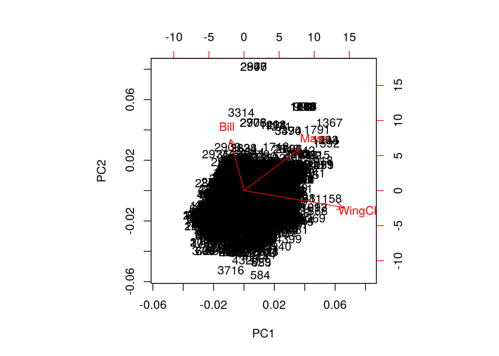

```r
#base package
biplot(prcomp(out))
```

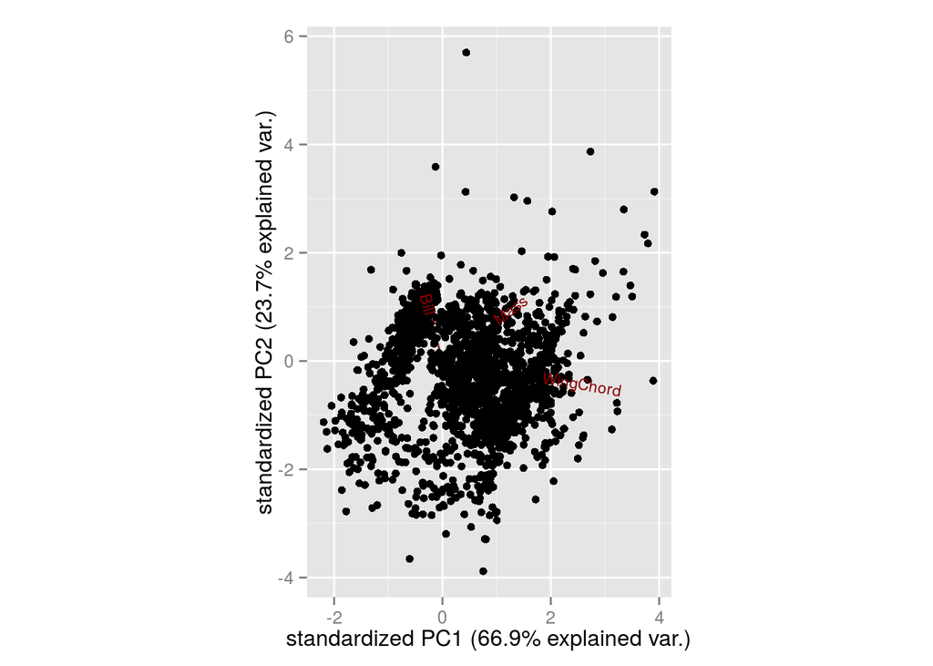

```r
#ggbiplot
ggbiplot((prcomp(out)))
```

Okay so that what it would look like in one time slice. Let’s add a new matrix, which is the future siteXspp.

Repeat trait calculation

```r
#container for site trait averages
outF<-matrix(nrow=ncol(siteXsppF),ncol=ncol(traits))

for (x in 1:ncol(siteXsppF)){
  #subset site
  site<-siteXsppF[,x]

  #get the trait matrix for species that are present
  site.trait<-traits[rownames(traits) %in% names(site[site==1]),]
  #mean position
  outF[x,]<-apply(site.trait,2,var)
}

#name container based on sites
rownames(outF)<-colnames(siteXsppF)
colnames(outF)<-colnames(traits)
```

## Approach #1: Bind the dataframes together

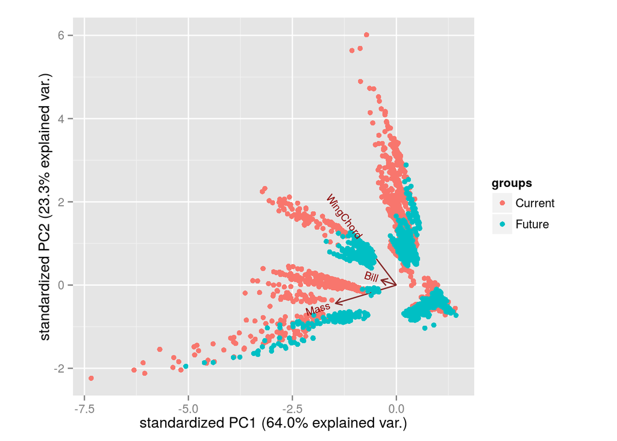

```r
combin<-rbind(out.var,outF)
pca<-princomp(combin)
#lets make a grouping variable, so the plot knows which is current and which is future
groups<-c(rep("Current",nrow(out.var)),rep("Future",nrow(outF)))
ggbiplot(pca,groups=groups)
```

So maybe we want to connect each assemblage by a faint line? Lots of different visualizations we could try

If the two data.frames out (current) and outF (future) are just bound together in a dataframe (combin), and they are ordered in the same manner, then the first row of combin is the current state of the assemblage and the 1+nrow(out) row of combin is the future state of that assemblage. If they are not ordered correctly, you could match off a row name or lookup table by cell number?

### Draw Lines

So as an example, line segements can be drawn in ggplot like this.

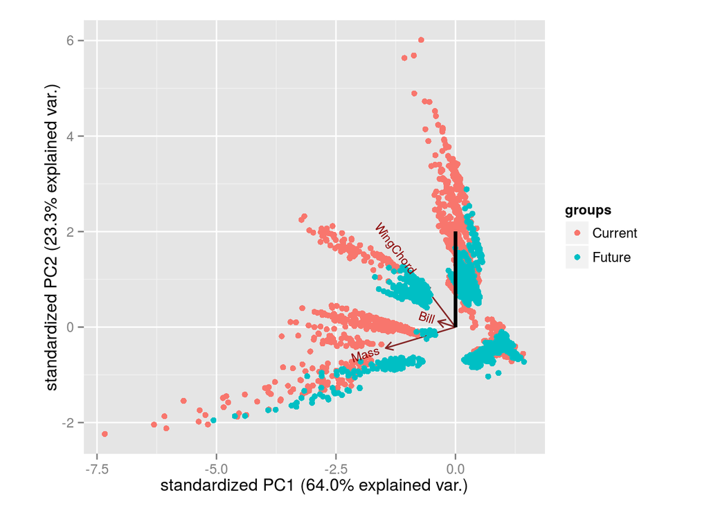

```r
ggbiplot(pca,groups=groups) + geom_segment(x=0,y=0,xend=0,yend=2,size=1)
```

So the goal is to get the pca coordinates of each pair, and pass them into geom_segement.

Step 1 is to get the correct pair for each line segement. The scores hold the pca loadings that act as coordinates in the figure. We just use the first two PC axis

As an example show the first site

```r
#begin coordinates
coords<-pca$scores[c(1,nrow(out)+1),1:2]

#rename to make more logical
colnames(coords)<-c("x","y")
rownames(coords)<-c("Begin","End")

#rearrange the data
mcoords<-melt(coords)
df<-dcast(mcoords,...~Var2+Var1)
df
```

```
##   . x_Begin  x_End y_Begin   y_End
## 1 .  0.9496 0.7208 -0.2598 -0.4051
```

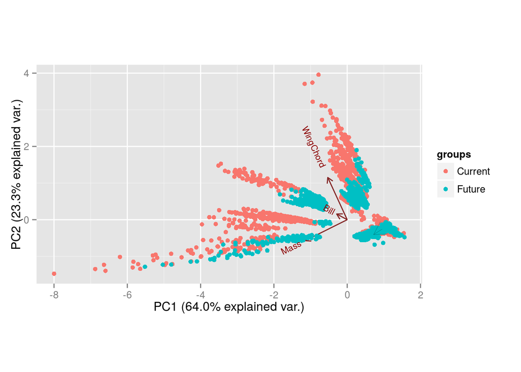

```r
ggbiplot(pca,groups=groups,scale = 0) + geom_segment(data=df,aes(x=x_Begin,y=y_Begin,xend=x_End,yend=y_End),size=.1,alpha=.5, arrow = arrow(length = unit(0.5,"cm")))
```

Repeat this all current assemblages.

```r
#begin coordinates
df<-list()

for (x in 1:nrow(out)){
coords<-pca$scores[c(x,nrow(out)+x),1:2]

#rename to make more logical
colnames(coords)<-c("x","y")
rownames(coords)<-c("Begin","End")

#rearrange the data
mcoords<-melt(coords)
df[[x]]<-dcast(mcoords,...~Var2+Var1)[,-1]
}

df<-rbind.fill(df)
```

plot

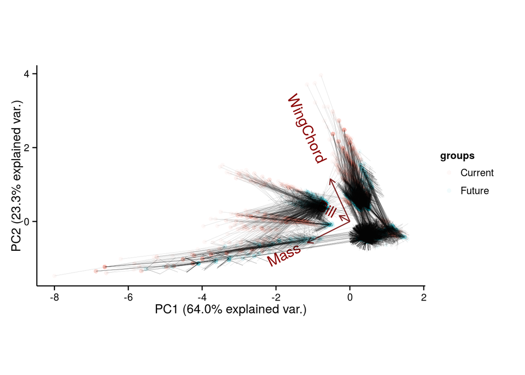

```r
ggbiplot(pca,groups=groups,scale = 0, varname.size = 5, alpha = 0.05) +
  geom_segment(data=df,aes(x=x_Begin,y=y_Begin,xend=x_End,yend=y_End),size=.1,alpha=.2, arrow = arrow(length = unit(0.5,"cm"))) +
  theme_classic()
```

It looks like, on the whole, the trait values are less variable going from the current to the future scenario (MPI-ESM-LR under the 8.5 representative concentration pathway). For wing chord and body mass, there are some arrows going against this.

If we want to look at the average direction / magnitude of change, we can take the average of the vectors and plot:

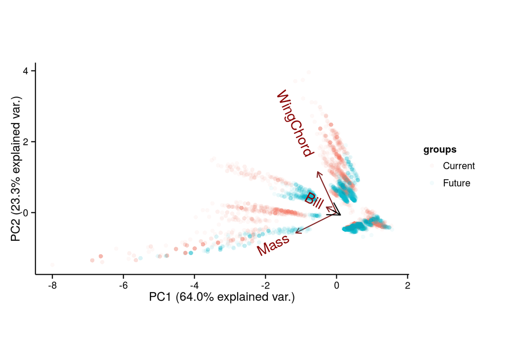

```r
# average of the vectors
df.sum <- data.frame(t(colMeans(df)))

ggbiplot(pca,groups=groups,scale = 0, varname.size = 5, alpha = 0.05) +
  geom_segment(data=df.sum,aes(x=x_Begin,y=y_Begin,xend=x_End,yend=y_End), arrow = arrow(length = unit(0.5,"cm"))) +
  theme_classic()
```

This gives us an idea of the direction the variation in trait values as a whole are moving from current to future (all getting less variable, bill length more so). The magnitude, like with the mean values, is small - because of the cells where the pattern is opposite to the majority.